# Exploratory Factor Analysis of Global Education Indicators

Theo Schouten, Owen Winecoff, Julia Masica

2025-09-18

## Data Loading and Preparation with Data Merging and Cleaning

We merged all datasets by country entity and cleaned the resulting dataframe to prepare for analysis.

```
## # A tibble: 6 × 10
##   Entity     Citations per documen…¹ expected_schooling mean_schooling GDP_share
##   <chr>                        <dbl>              <dbl>          <dbl>     <dbl>
## 1 Algeria                      13.7                15.5           7.42      5.61
## 2 Angola                        7.52               12.2           5.96      2.51
## 3 Armenia                      17.4                14.4          11.3       2.43
## 4 Australia                    24.8                20.7          12.9       5.21
## 5 Austria                      22.0                16.3          12.4       4.77
## 6 Azerbaijan                   15.6                12.9          11.1       3.58
## # ℹ abbreviated name: ¹`Citations per document`
## # ℹ 5 more variables: primary_water <dbl>, upper_secondary_water <dbl>,
## #   lower_secondary_water <dbl>, mean_rights <dbl>, density_per_km <dbl>
```

## Descriptive Statistics

```
##                        vars  n   mean     sd median trimmed    mad   min
## Citations per document    1 95  18.46   6.74  18.14   18.06   6.40  6.29
## expected_schooling        2 95  14.11   2.98  14.16   14.17   2.96  7.90
## mean_schooling            3 95   9.31   3.34  10.10    9.56   3.84  1.41
## GDP_share                 4 95   4.40   1.57   4.32    4.36   1.50  0.38
## primary_water             5 95  82.17  24.46  99.13   86.47   1.29 17.74
## upper_secondary_water     6 95  87.85  19.19 100.00   91.80   0.00 14.55
## lower_secondary_water     7 95  85.99  21.86 100.00   90.19   0.00  9.21
## mean_rights               8 95   0.46   0.20   0.43    0.45   0.19  0.10
## density_per_km            9 95 289.02 897.09 107.14  141.94 116.53  3.40
##                            max   range  skew kurtosis    se
## Citations per document   45.18   38.89  0.91     1.85  0.69
## expected_schooling       20.65   12.76 -0.14    -0.61  0.31
## mean_schooling           14.30   12.88 -0.54    -0.79  0.34
## GDP_share                 8.54    8.15  0.28     0.23  0.16
## primary_water           100.00   82.26 -1.22     0.25  2.51
## upper_secondary_water   100.00   85.45 -1.66     1.91  1.97
## lower_secondary_water   100.00   90.79 -1.51     1.28  2.24
## mean_rights               0.87    0.77  0.39    -0.83  0.02
## density_per_km         8416.46 8413.06  7.94    68.12 92.04
```

## Univariate Visualizations

Based on the feedback from EDA, we changed our graphs to visualize each variable as a one-dimensional dot plot to better show the distribution of values across countries.

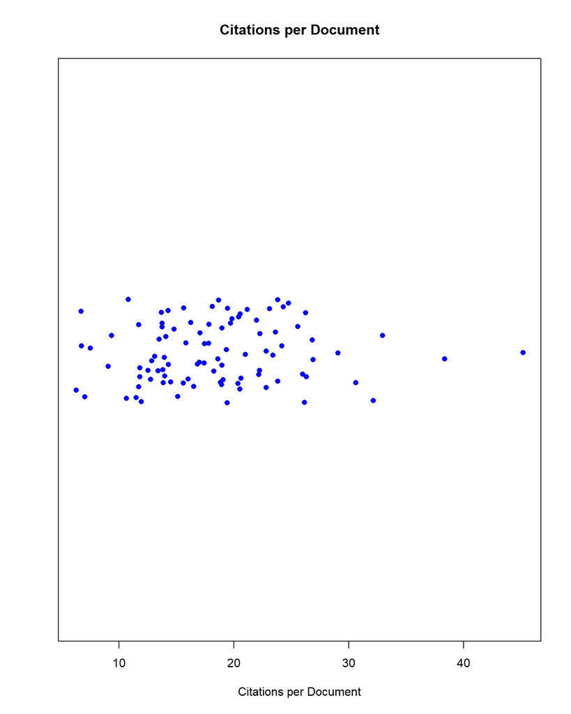

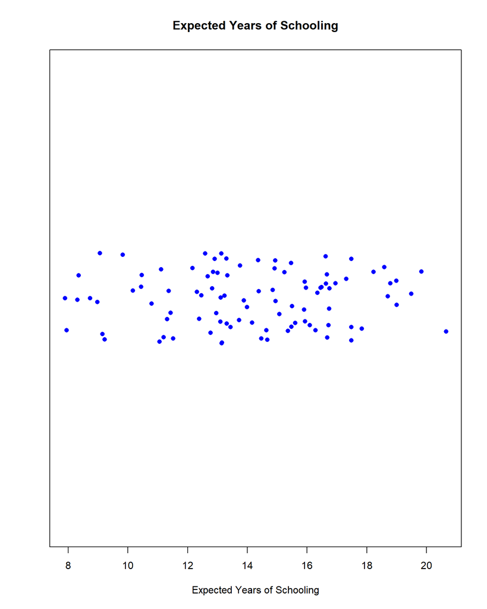

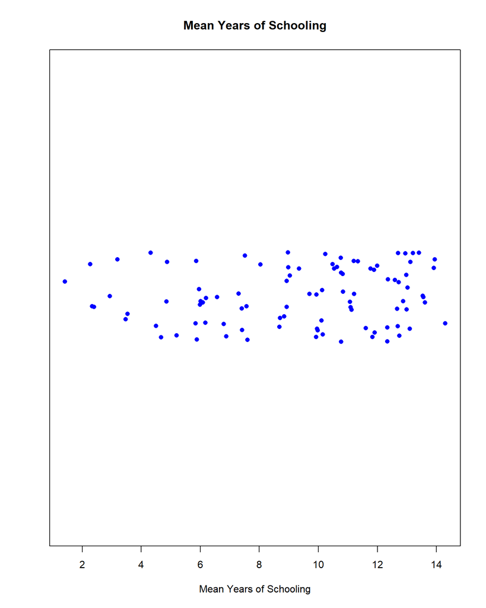

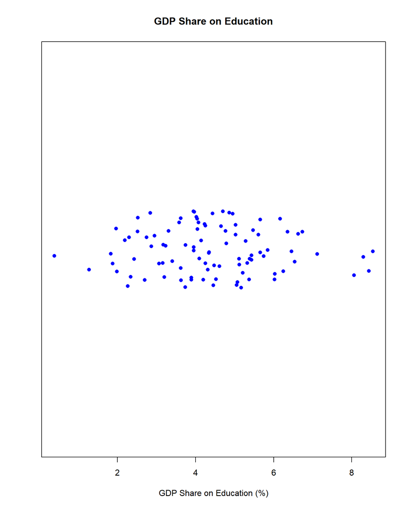

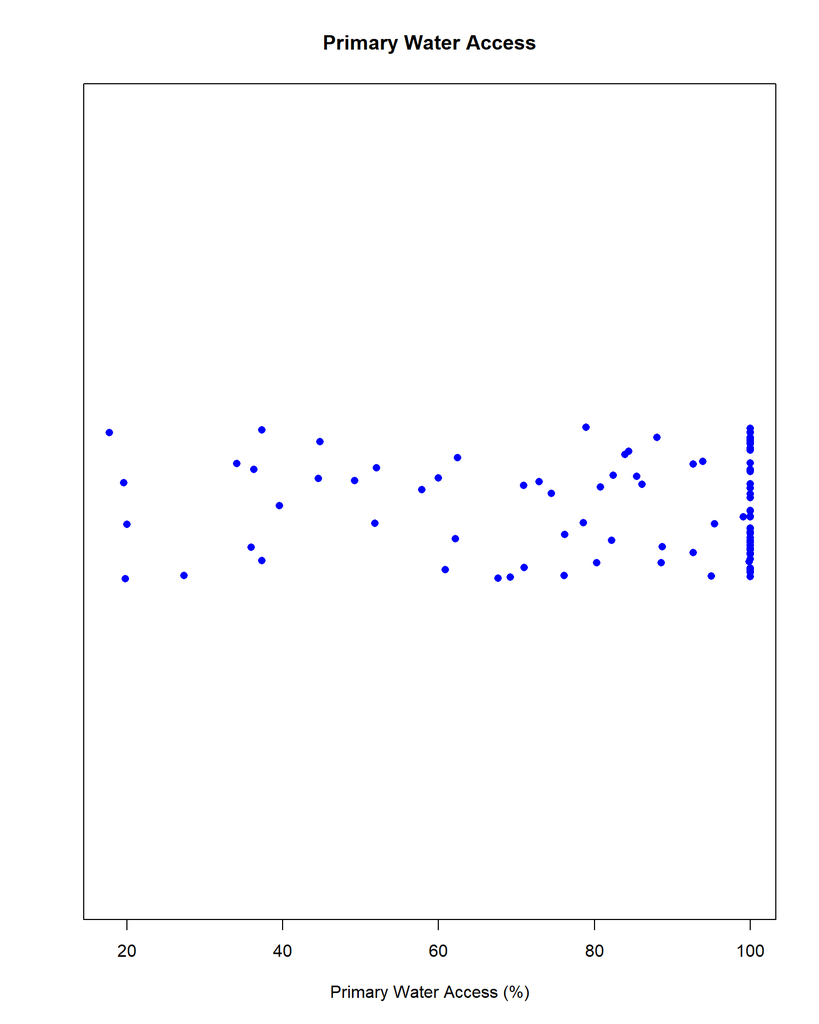

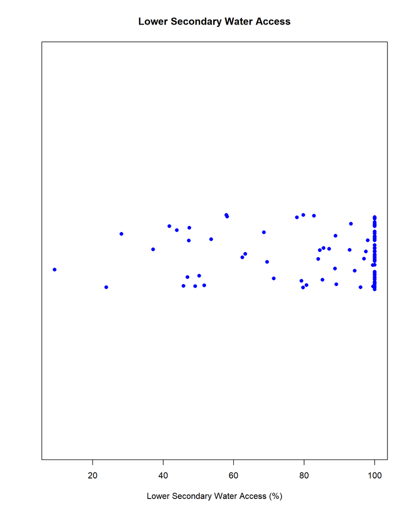

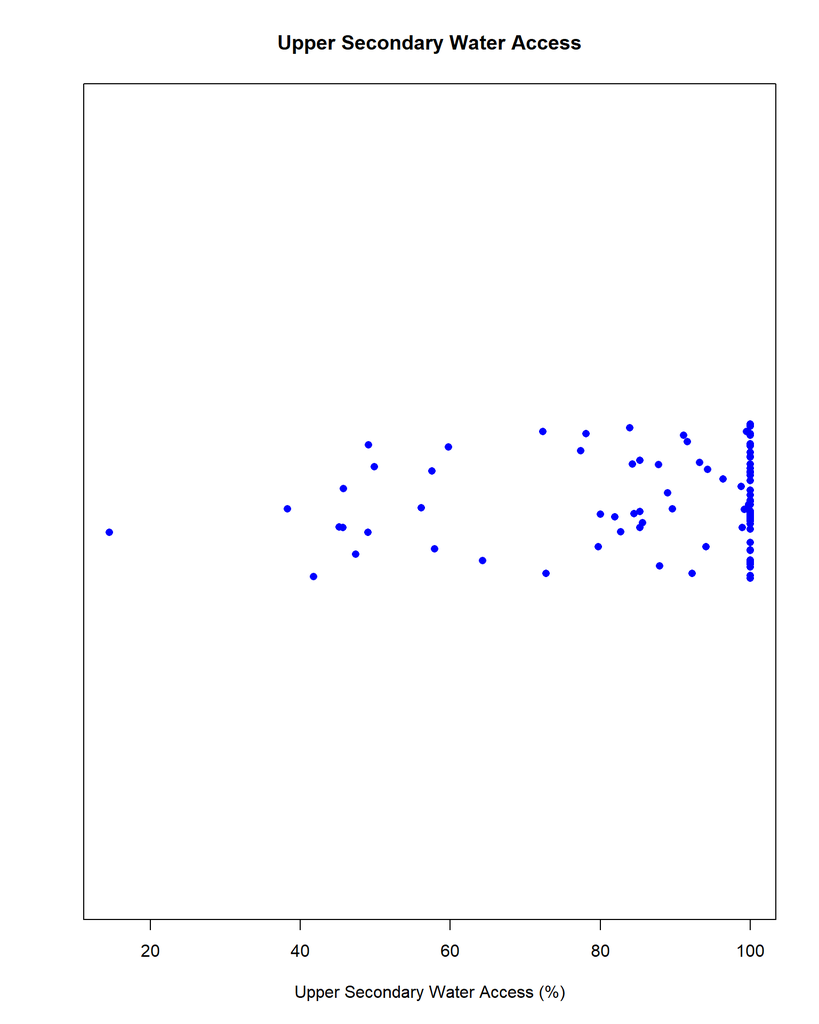

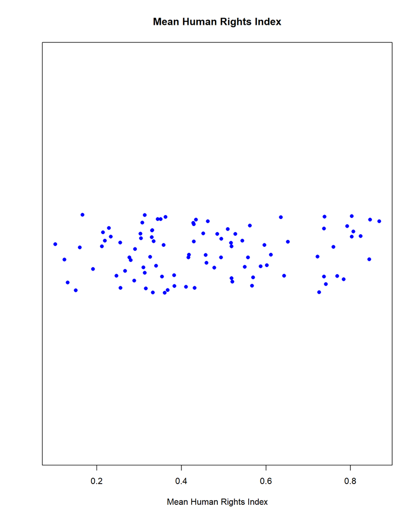

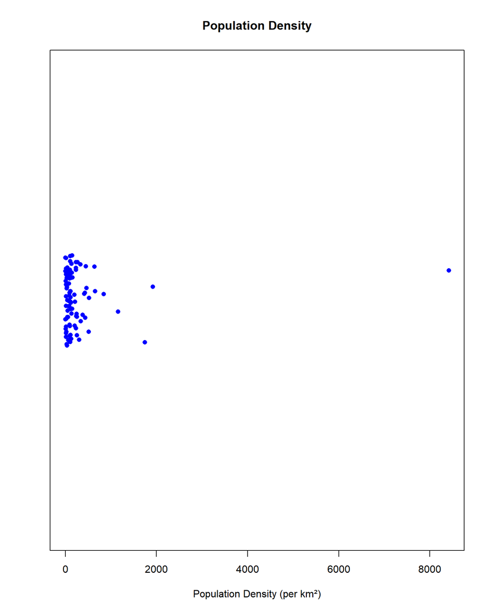

## Bivariate Relationships

We examine the pairwise relationships between all variables to understand their covariance structure.

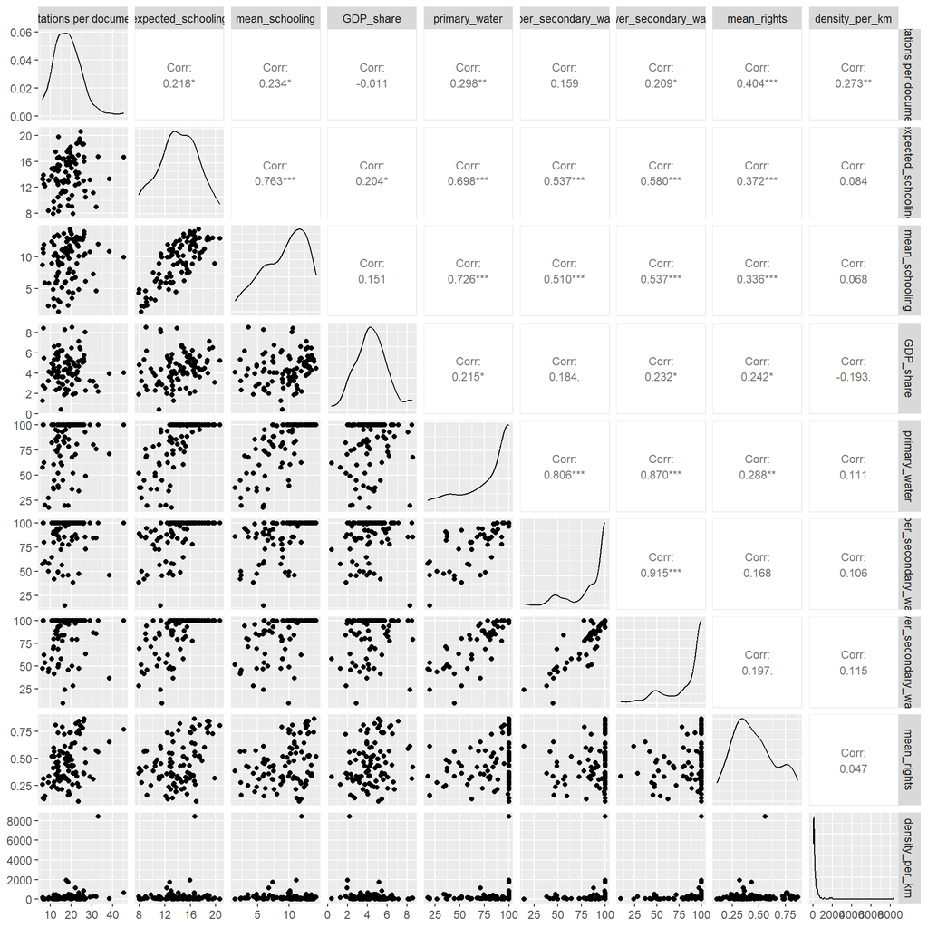

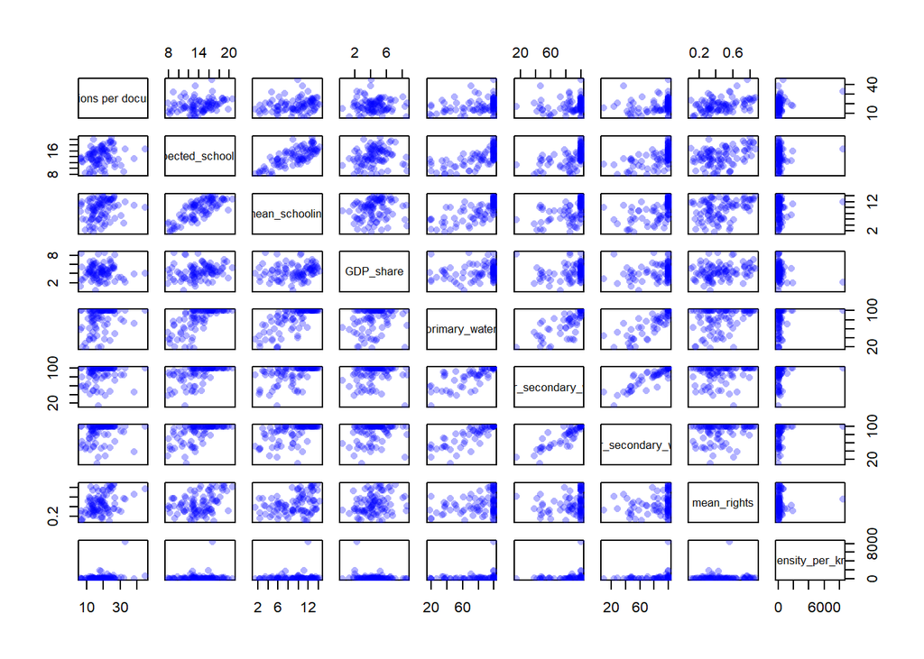

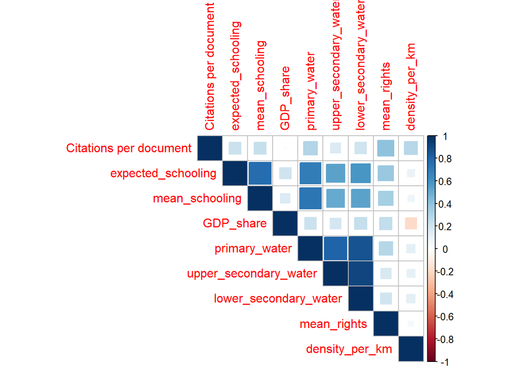

## Outlier Detection

We use Mahalanobis distance to identify multivariate outliers in our dataset.

```
## Outlier indices: 9 17 58 59 62 64 77 80
```

```
## Countries identified as outliers:
```

```
## # A tibble: 8 × 10
##   Entity      Citations per docume…¹ expected_schooling mean_schooling GDP_share
##   <chr>                        <dbl>              <dbl>          <dbl>     <dbl>
## 1 Barbados                      45.2              16.6            9.93      4.04
## 2 Cambodia                      15.6              11.2            5.20      2.95
## 3 Nicaragua                     16.0              11.5            9.93      2.87
## 4 Niger                         14                 8.31           1.41      4.07
## 5 Pakistan                      21                 7.90           4.32      1.88
## 6 Panama                        38.4              13.3           10.8       3.94
## 7 Singapore                     33.0              16.7           12.0       2.19
## 8 Solomon Is…                   17.1              11.3            5.88      8.29
## # ℹ abbreviated name: ¹`Citations per document`
## # ℹ 5 more variables: primary_water <dbl>, upper_secondary_water <dbl>,
## #   lower_secondary_water <dbl>, mean_rights <dbl>, density_per_km <dbl>
```

### Outlier Characterization

Let’s examine what makes these countries outliers by comparing them to the overall dataset statistics.

```
##          Citations per document expected_schooling mean_schooling GDP_share
## 1                         45.18              16.63           9.93      4.04
## 2                         15.60              11.20           5.20      2.95
## 3                         16.03              11.51           9.93      2.87
## 4                         14.00               8.31           1.41      4.07
## 5                         21.00               7.90           4.32      1.88
## 6                         38.37              13.31          10.83      3.94
## 7                         32.96              16.74          11.99      2.19
## 8                         17.06              11.31           5.88      8.29
## Mean                      18.46              14.11           9.31      4.40
## Mean+2SD                  31.94              20.07          15.99      7.55
## Mean-2SD                   4.97               8.16           2.64      1.26
##          primary_water upper_secondary_water lower_secondary_water mean_rights
## 1               100.00                100.00                100.00        0.77
## 2                60.00                 56.17                 84.43        0.31
## 3                44.59                 45.17                  9.21        0.33
## 4                37.29                 85.62                 51.67        0.38
## 5                52.01                 38.29                 28.17        0.36
## 6                70.97                 45.71                 37.17        0.65
## 7               100.00                100.00                100.00        0.56
## 8                19.56                 14.55                 23.89        0.61
## Mean             82.17                 87.85                 85.99        0.46
## Mean+2SD        131.09                126.22                129.71        0.85
## Mean-2SD         33.26                 49.48                 42.27        0.06
##          density_per_km
## 1                654.97
## 2                 92.62
## 3                 53.30
## 4                 20.69
## 5                267.40
## 6                 58.46
## 7               8416.46
## 8                 25.06
## Mean             289.02
## Mean+2SD        2083.19
## Mean-2SD       -1505.16
```

### Impact of Outliers on Correlations

```
## Correlation differences (with outliers - without outliers):
```

```
##                        Citations per document expected_schooling mean_schooling
## Citations per document                  0.000              0.007          0.000
## expected_schooling                      0.007              0.000          0.019
## mean_schooling                          0.000              0.019          0.000
## GDP_share                              -0.071             -0.007         -0.020
## primary_water                          -0.035              0.031          0.004
## upper_secondary_water                  -0.125              0.023         -0.040
## lower_secondary_water                  -0.149              0.025         -0.051
## mean_rights                             0.041              0.003         -0.003
## density_per_km                          0.114              0.130          0.125
##                        GDP_share primary_water upper_secondary_water
## Citations per document    -0.071        -0.035                -0.125
## expected_schooling        -0.007         0.031                 0.023
## mean_schooling            -0.020         0.004                -0.040
## GDP_share                  0.000        -0.070                -0.091
## primary_water             -0.070         0.000                -0.012
## upper_secondary_water     -0.091        -0.012                 0.000
## lower_secondary_water     -0.073        -0.034                -0.009
## mean_rights                0.005        -0.017                -0.055
## density_per_km            -0.027         0.036                 0.014
##                        lower_secondary_water mean_rights density_per_km
## Citations per document                -0.149       0.041          0.114
## expected_schooling                     0.025       0.003          0.130
## mean_schooling                        -0.051      -0.003          0.125
## GDP_share                             -0.073       0.005         -0.027
## primary_water                         -0.034      -0.017          0.036
## upper_secondary_water                 -0.009      -0.055          0.014
## lower_secondary_water                  0.000      -0.054         -0.004
## mean_rights                           -0.054       0.000          0.078
## density_per_km                        -0.004       0.078          0.000
```

The outliers primarily affect correlations between citations and water access variables, as well as between population density and schooling metrics (likely due to Singapore’s extreme density).

## Exploratory Factor Analysis

### Defining Variable Sets

For our factor analysis, we separate our variables into two groups:

- **Response variables**: Expected schooling, mean human rights, and GDP share for education
- **Predictor variables**: All remaining variables (citations, mean schooling, water access measures, population density)

### Determining Intrinsic Dimensionality

We use multiple criteria to determine the appropriate number of factors for each variable set.

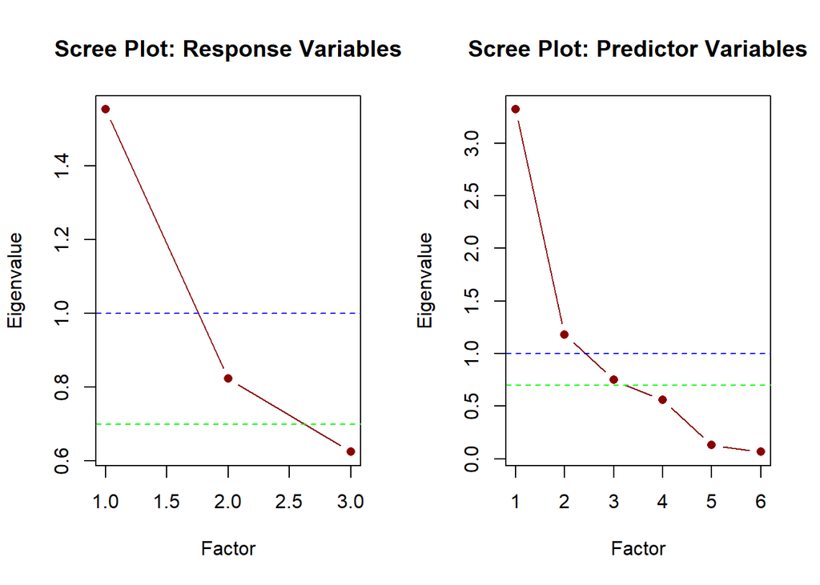

```
## Response Variables:
```

```
## Kaiser's criterion (eigenvalue > 1): 1
```

```
## Jolliffe's criterion (eigenvalue > 0.7): 1 2
```

```
## Predictor Variables:
```

```
## Kaiser's criterion (eigenvalue > 1): 1 2
```

```
## Jolliffe's criterion (eigenvalue > 0.7): 1 2 3
```

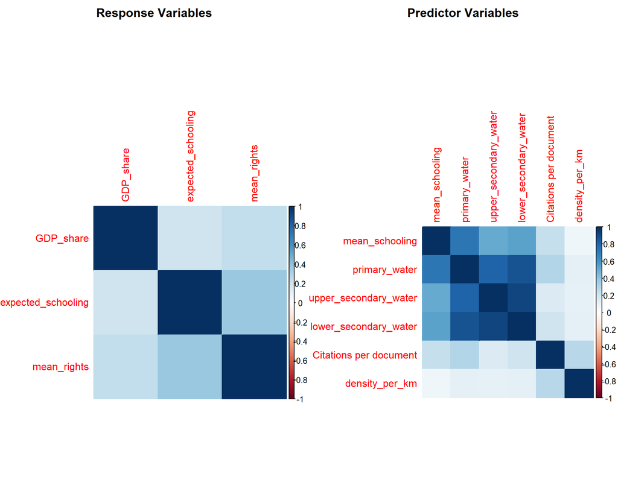

### Interpretation of Dimensionality Criteria

We plotted the eigenvalues for both the predictor and response variable sets. In both scree plots there was a clear elbow after the first factor, suggesting an intrinsic dimensionality of one. Next we applied both Jolliffe’s and Kaiser’s criteria:

To decide which criterion fits our data best, we examined the correlation plots. The correlation plots showed the response variables formed two moderately correlated clusters, while the predictor variables showed three distinct clusters. Because Jolliffe’s criterion aligned more closely with these observed patterns in the correlation structure, we decided to use Jolliffe’s criterion (2 factors for responses, 3 factors for predictors).

## Factor Rotation and Selection

We compare orthogonal (varimax) and oblique (oblimin) rotations to determine which provides the most interpretable factor structure.

```
## Response Variables - Orthogonal Rotation (2 factors):
```

```
##                      RC1   RC2
## expected_schooling 0.847 0.041
## GDP_share          0.140 0.986
## mean_rights        0.793 0.183
```

```
##
## Variance explained (1 factor): 0.517
```

```
## Variance explained (2 factors): 0.456 0.336
```

```
## Total variance (2 factors): 0.792
```

```
## Predictor Variables - Orthogonal Rotation (3 factors):
```

```
##                          RC1    RC3    RC2
## Citations per document 0.118  0.943  0.173
## mean_schooling         0.711  0.338 -0.125
## primary_water          0.932  0.216  0.022
## upper_secondary_water  0.930 -0.042  0.111
## lower_secondary_water  0.947  0.023  0.105
## density_per_km         0.051  0.151  0.972
```

```
##
## Variance explained (1 factor): 0.553
```

```
## Variance explained (3 factors): 0.526 0.179 0.169
```

```
## Total variance (3 factors): 0.874
```

### Visual Comparison of Rotation Methods

#### Response Variables: Factor Correlations

```
## Factor Correlations (Oblique Rotation - Response Variables):
```

```
##       TC1   TC2
## TC1 1.000 0.258
## TC2 0.258 1.000
```

```
##
## Interpretation:
```

```
## Factor correlations are low (< 0.3), suggesting orthogonal rotation is appropriate.
```

#### Response Variables: Loading Plots

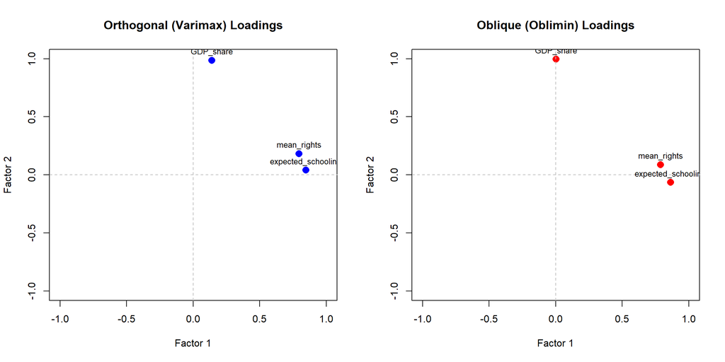

#### Predictor Variables: Factor Correlations

```
## Factor Correlations (Oblique Rotation - Predictor Variables):
```

```
##       TC1   TC3   TC2
## TC1 1.000 0.225 0.087
## TC3 0.225 1.000 0.195
## TC2 0.087 0.195 1.000
```

```
##
## Interpretation:
```

```
## Factor correlations are low (< 0.3), suggesting orthogonal rotation is appropriate.
```

### Selection of Rotation Method

Using Jolliffe’s criterion, we compared orthogonal and oblique rotations to determine which would best simplify our data. We examined both factor correlations and loading plots to make this decision.

**For Response Variables:**

**For Predictor Variables:**

**Conclusion:** We selected the orthogonal (varimax) rotation for both variable sets because:

## Final Factor Model Summary

```
##  RESPONSE VARIABLES (2 factors)
```

```
##                      RC1   RC2
## expected_schooling 0.847 0.041
## GDP_share          0.140 0.986
## mean_rights        0.793 0.183
```

```
##
## Variance explained by each factor:
```

```
##   RC1   RC2
## 0.456 0.336
```

```
## Total variance retained: 0.792 ( 79.2 %)
```

```
##  PREDICTOR VARIABLES (3 factors)
```

```
##                          RC1    RC3    RC2
## Citations per document 0.118  0.943  0.173
## mean_schooling         0.711  0.338 -0.125
## primary_water          0.932  0.216  0.022
## upper_secondary_water  0.930 -0.042  0.111
## lower_secondary_water  0.947  0.023  0.105
## density_per_km         0.051  0.151  0.972
```

```
##
## Variance explained by each factor:
```

```
##   RC1   RC3   RC2
## 0.526 0.179 0.169
```

```
## Total variance retained: 0.874 ( 87.4 %)
```

### Model Fit Assessment

We assess how well the factor model reconstructs the original correlation matrices by computing residuals.

```
## Response Variables - Correlation Residuals:
```

```
##                    expected_schooling GDP_share mean_rights
## expected_schooling             0.2804    0.0454     -0.3075
## GDP_share                      0.0454    0.0074     -0.0498
## mean_rights                   -0.3075   -0.0498      0.3373
```

```
##
##
## Predictor Variables - Correlation Residuals:
```

```
##                        Citations per document mean_schooling primary_water
## Citations per document                 0.0662        -0.1475       -0.0199
## mean_schooling                        -0.1475         0.3642       -0.0072
## primary_water                         -0.0199        -0.0072        0.0833
## upper_secondary_water                  0.0688        -0.1242       -0.0548
## lower_secondary_water                  0.0569        -0.1313       -0.0207
## density_per_km                        -0.0442         0.1015        0.0092
##                        upper_secondary_water lower_secondary_water
## Citations per document                0.0688                0.0569
## mean_schooling                       -0.1242               -0.1313
## primary_water                        -0.0548               -0.0207
## upper_secondary_water                 0.1203                0.0228
## lower_secondary_water                 0.0228                0.0915
## density_per_km                       -0.0431               -0.0390
##                        density_per_km
## Citations per document        -0.0442
## mean_schooling                 0.1015
## primary_water                  0.0092
## upper_secondary_water         -0.0431
## lower_secondary_water         -0.0390
## density_per_km                 0.0298
```

## Conclusions

The analysis reveals distinct latent dimensions in both variable sets:

## Structural Equation Modeling

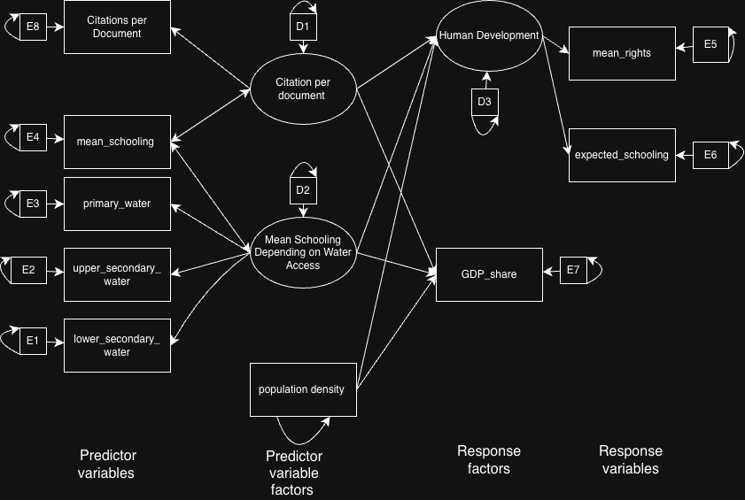

### Model Specification and Estimation

```
## lavaan 0.6-19 ended normally after 50 iterations
##
##   Estimator                                         ML
##   Optimization method                           NLMINB
##   Number of model parameters                        23
##
##   Number of observations                            95
##
## Model Test User Model:
##
##   Test statistic                               121.720
##   Degrees of freedom                                21
##   P-value (Chi-square)                           0.000
##
## Parameter Estimates:
##
##   Standard errors                             Standard
##   Information                                 Expected
##   Information saturated (h1) model          Structured
##
## Latent Variables:
##                           Estimate  Std.Err  z-value  P(>|z|)
##   CitationPerDocument =~
##     Citatinprdcmnt           1.000
##   HumanDevelopment =~
##     mean_rights              1.000
##     expectd_schlng           1.957    0.579    3.379    0.001
##   Mean_Schooling_Water =~
##     primary_water            1.000
##     uppr_scndry_wt           1.024    0.067   15.188    0.000
##     lwr_scndry_wtr           1.070    0.063   17.031    0.000
##
## Regressions:
##                      Estimate  Std.Err  z-value  P(>|z|)
##   HumanDevelopment ~
##     populatn_dnsty     -0.011    0.040   -0.263    0.793
##     CitatinPrDcmnt      0.070    0.045    1.531    0.126
##     Men_Schlng_Wtr      0.336    0.104    3.240    0.001
##   GDP_share ~
##     populatn_dnsty     -0.220    0.097   -2.259    0.024
```

[output cut: 12 more lines]

```
##    .GDP_share                0.044    0.040    1.094    0.274
##
## Variances:
##                    Estimate  Std.Err  z-value  P(>|z|)
##    .Citatinprdcmnt    0.000
##    .mean_rights       0.801    0.125    6.434    0.000
##    .expectd_schlng    0.269    0.175    1.534    0.125
##    .primary_water     0.180    0.033    5.538    0.000
##    .uppr_scndry_wt    0.140    0.028    4.945    0.000
##    .lwr_scndry_wtr    0.063    0.023    2.746    0.006
##    .GDP_share         0.889    0.129    6.872    0.000
##     mean_schooling    0.989    0.144    6.892    0.000
##     CitatinPrDcmnt    0.989    0.144    6.892    0.000
##    .HumanDevelpmnt    0.083    0.046    1.808    0.071
##     Men_Schlng_Wtr    0.809    0.142    5.679    0.000
```

### Model Identification and Degrees of Freedom

```
##  MODEL IDENTIFICATION
```

```
## Number of observed variables: 9
```

```
## Observed statistics (variances + covariances): 45
```

```
## Estimated parameters: 23
```

```
## Degrees of freedom: 21
```

```
## Model is OVER-identified (df > 0)
## This means the model can be properly estimated and tested.
```

The model is over-identified with positive degrees of freedom, meaning it can be properly estimated and statistically tested.

### Significant Predictors of Response Variables

```
##  SIGNIFICANT PARAMETERS (|z| > 1.96)
```

```
##                      lhs op                   rhs    est    se      z pvalue
## 1   Mean_Schooling_Water =~ lower_secondary_water  1.070 0.063 17.031  0.000
## 2   Mean_Schooling_Water =~ upper_secondary_water  1.024 0.067 15.188  0.000
## 3         mean_schooling ~~        mean_schooling  0.989 0.144  6.892  0.000
## 4    CitationPerDocument ~~   CitationPerDocument  0.989 0.144  6.892  0.000
## 5              GDP_share ~~             GDP_share  0.889 0.129  6.872  0.000
## 6            mean_rights ~~           mean_rights  0.801 0.125  6.434  0.000
## 7   Mean_Schooling_Water ~~  Mean_Schooling_Water  0.809 0.142  5.679  0.000
## 8          primary_water ~~         primary_water  0.180 0.033  5.538  0.000
## 9  upper_secondary_water ~~ upper_secondary_water  0.140 0.028  4.945  0.000
## 10  Mean_Schooling_Water ~~        mean_schooling  0.548 0.112  4.889  0.000
## 11      HumanDevelopment =~    expected_schooling  1.957 0.579  3.379  0.001
## 12      HumanDevelopment  ~  Mean_Schooling_Water  0.336 0.104  3.240  0.001
## 13 lower_secondary_water ~~ lower_secondary_water  0.063 0.023  2.746  0.006
## 14             GDP_share  ~  Mean_Schooling_Water  0.285 0.113  2.514  0.012
```

[output cut: 21 more lines]

```
##
##  Predictors of Human Development
```

```
##                    rhs   est    se    z pvalue
## 1 Mean_Schooling_Water 0.336 0.104 3.24  0.001
```

```
##
##  Predictors of GDP Share on Education
```

```
##                    rhs    est    se      z pvalue
## 1 Mean_Schooling_Water  0.285 0.113  2.514  0.012
## 2   population_density -0.220 0.097 -2.259  0.024
```

**For Human Development:**

**For GDP Share on Education:**

Two variables significantly predict the percentage of GDP allocated to education. First, Mean_Schooling_Water shows a positive effect (β = 0.285, z = 2.514, p = 0.012), indicating that countries with better water infrastructure in schools tend to invest more of their GDP in education. This suggests a virtuous cycle where infrastructure investment and education funding reinforce each other. Second, population_density shows a negative effect (β = -0.220, z = -2.259, p = 0.024), meaning that more densely populated countries allocate a smaller share of GDP to education. This finding might seem counter intuitive because of dense but rich countries like Singapore, but the general effect is negative because most densely populated countries are poorer and have poorer living qualities unlike singapore, like Bangladesh.

### Model Fit Evaluation

```
##  MODEL FIT INDICES
```

```
##   chisq      df  pvalue     cfi     tli   rmsea    srmr     gfi    agfi
## 121.720  21.000   0.000   0.802   0.660   0.225   0.103   0.753   0.472
```

```
##
##
## Fit Assessment Guidelines:
```

```
## - CFI/TLI > 0.95 = excellent fit, > 0.90 = acceptable
```

```
## - RMSEA < 0.06 = excellent fit, < 0.08 = acceptable
```

```
## - SRMR < 0.08 = good fit
```

```
## - Chi-square p-value > 0.05 = good fit (sensitive to sample size)
```

The model demonstrates **poor to marginal overall fit** to the data:

- **CFI = 0.802**: This falls below the 0.90 cutoff for an acceptable fit. A CFI of 0.802 indicates that our model explains only 80.2% of the covariance in the data compared to a baseline independence model, suggesting that important relationships or structural elements may be missing from our specification.
- **TLI = 0.660**: The Tucker-Lewis Index is also far below the acceptable range (< 0.90), which further supports the conclusion that the model fits poorly. This low TLI value suggests the model may be more complicated than it needs to be without providing much improvement over a simpler version.
- **RMSEA = 0.225** This considerably exceeds the 0.08 cutoff for acceptable fit and even surpasses the 0.10 threshold typically considered poor fit. An RMSEA above 0.20 indicates substantial approximation error, meaning the model does not closely reproduce the observed covariance structure.
- **SRMR = 0.103**: This exceeds the 0.08 threshold for good fit, meaning that standardized residuals are larger than they should be. However, among all the fit indices, this one is the least concerning.
- **Chi-square = 121.720** (df = 21, p < 0.001): The highly significant chi-square test indicates that our model’s implied covariance matrix differs significantly from the observed covariance matrix, rejecting the null hypothesis of perfect fit.

**Overall Assessment:** The current model does **not** fit the data well. Multiple fit indices consistently indicate poor fit, suggesting that our hypothesized relationships do not align well with the observed patterns across countries. Our model may be missing important direct paths, correlated errors, or moderating relationships. Despite finding statistically significant predictors, the overall structural specification requires revision to better capture the complex relationships in global education data. Potential improvements could include reconsidering the factor structure or exploring alternative theoretical frameworks.

**Abstract:**

**Building the Future: Factors of Global Education**

**Introduction**

Global Education systems face constant inequalities in resources and infrastructure that impact human development and education. Millions of children around the world are affected by this every day. Understanding the relationships between educational investment, infrastructure quality, and broader developmental outcomes is critical for informing global policy decisions. This study examines multidimensional factors of global education to identify which variables most strongly predict human development and educational investment across many nations. By revealing some of the core forces shaping the state of global education, our study offers guidance to more effective methods of improving education systems and outcomes worldwide.

**Methods**

With this in mind, we analyzed data from 95 countries using variables from Our World in Data and other international sources. Response variables included expected years of schooling, human rights index, and GDP share allocated to education. Predictor variables encompassed research citations per document, mean years of schooling, water access across three education levels, and population density. We conducted exploratory factor analysis using multiple criteria to determine intrinsic dimensionality and compare varimax and oblimin rotations. Subsequently, we specified a structural equation model (SEM) to test hypothesized relationships between latent factors and response variables, evaluating model fit using CFI, TLI, RMSEA, and SRMR indices.

**Results**

**Conclusion**

Basic educational infrastructure, particularly water access in schools, shows up as the strongest predictor of both human development outcomes and educational investment priorities across countries. This highlights the crucial role of foundational infrastructure in developmental gains, which suggests that global education efforts should prioritize the provision of basic resources. The poor model fit indicates complex relationships that require further analysis to capture and model global education dynamics more appropriately.